# Classificação de subscrições de serviço - Disciplina de Análise Preditiva Avançada do MBA em Business Analytics e Big Data - FGV-RJ

```r
knitr::opts_chunk$set(echo = TRUE)
```

## Instalando bibliotecas

```r
library(tidyverse)
library(lubridate)
library(naniar)
library(VIM)
library(corrplot)
library(psych)
library(inspectdf)
library(mlbench)
library(ModelMetrics)
library(caret)
library(forcats)
library(h2o)
library(mice)
library(pROC)
library(pdp)
```

## Importando a base de dados

```
## 'data.frame':    41188 obs. of  19 variables:
##  $ AGE           : int  56 57 37 40 56 45 59 41 24 25 ...
##  $ JOB           : chr  "housemaid" "services" "services" "admin" ...
##  $ MARITAL_STATUS: chr  "married" "married" "married" "married" ...
##  $ EDUCATION     : chr  "basic_4y" "high_school" "high_school" "basic_6y" ...
##  $ DEFAULT       : chr  "no" "unknown" "no" "no" ...
##  $ HOUSING       : chr  "no" "no" "yes" "no" ...
##  $ LOAN          : chr  "no" "no" "no" "no" ...
##  $ CONTACT       : chr  "telephone" "telephone" "telephone" "telephone" ...
##  $ MONTH         : chr  "may" "may" "may" "may" ...
##  $ DAY_OF_WEEK   : chr  "mon" "mon" "mon" "mon" ...
##  $ DURATION      : int  261 149 226 151 307 198 139 217 380 50 ...
##  $ CAMPAIGN      : int  1 1 1 1 1 1 1 1 1 1 ...
##  $ PDAYS         : int  -1 -1 -1 -1 -1 -1 -1 -1 -1 -1 ...
##  $ PREVIOUS      : int  0 0 0 0 0 0 0 0 0 0 ...
##  $ POUTCOME      : chr  "nonexistent" "nonexistent" "nonexistent" "nonexistent" ...
##  $ EMP_VAR_RATE  : chr  "1_1" "1_1" "1_1" "1_1" ...
##  $ CONS_PRICE_IDX: chr  "93.994" "93.994" "93.994" "93.994" ...
##  $ CONS_CONF_IDX : chr  "-36_4" "-36_4" "-36_4" "-36_4" ...
##  $ SUBSCRIBED    : chr  "no" "no" "no" "no" ...
```

### Observando os levels das seguintes colunas

```r
varlist <- c("JOB", "MARITAL_STATUS", "EDUCATION","CONTACT", "HOUSING","LOAN", "SUBSCRIBED", "DEFAULT")
lapply(marketing[varlist], table)
```

```
## $JOB
##
##         admin   blue-collar  entrepreneur     housemaid    management
##         10422          9254          1456          1060          2924
##       retired self-employed      services       student    technician
##          1720          1421          3969           875          6743
##    unemployed       unknown
##          1014           330
##
## $MARITAL_STATUS
##
## divorced  married   single  unknown
##     4612    24928    11568       80
##
## $EDUCATION
##
##            basic_4y            basic_6y            basic_9y         high_school
##                4176                2292                6045                9515
##          illiterate professional_course   university_degree             unknown
##                  18                5243               12168                1731
##
## $CONTACT
##
##  cellular telephone
##     26144     15044
##
## $HOUSING
##
##      no unknown     yes
##   18622     990   21576
##
## $LOAN
##
##      no unknown     yes
##   33950     990    6248
##
## $SUBSCRIBED
##
##    no   yes
## 36548  4640
##
## $DEFAULT
##
##      no unknown     yes
##   32588    8597       3
```

### Verificando se existem NA’s

```r
sapply(marketing, function(x) sum(is.na(x)))
```

```
##            AGE            JOB MARITAL_STATUS      EDUCATION        DEFAULT
##              0              0              0              0              0
##        HOUSING           LOAN        CONTACT          MONTH    DAY_OF_WEEK
##              0              0              0              0              0
##       DURATION       CAMPAIGN          PDAYS       PREVIOUS       POUTCOME
##              0              0              0              0              0
##   EMP_VAR_RATE CONS_PRICE_IDX  CONS_CONF_IDX     SUBSCRIBED
##              0              0              0              0
```

### Transformando em factor as seguintes variáveis “JOB”, “MARITAL_STATUS”,“CONTACT”,“DEFAULT”,“HOUSING”,“LOAN”,“MONTH”,“DAY_OF_WEEK”,“POUTCOME” e “SUBSCRIBED”

```r
varlist2 <- c("JOB", "MARITAL_STATUS","CONTACT","DEFAULT","HOUSING","LOAN","MONTH","DAY_OF_WEEK","POUTCOME", "SUBSCRIBED")
marketing[varlist2] <- lapply(marketing[varlist2], as.factor)
```

Como não existe categoria “desconhecida” (unknown) para o pagamento de contas atrasasadas e o número de observações de inadimplentes (‘yes) é extremamente baixo, iremos considerar todos os ’unknown’ como ‘no’.

```r
marketing$DEFAULT <- gsub("unknown", "no", marketing$DEFAULT)
```

### Tratando os valores da variável ‘HOUSING’

Como o valor ‘unknow’ representa um NA e não podemos atribuir como sim ou não essas observações serão removidas da base, assim 990 observações serão removidas.

Os valores ‘unknown’ para LOAN foram removidos junto com as observações da variável ‘HOUSING’, pois os NA’s estavam presentes nas mesma linhas para as duas variáveis

```r
marketing <- marketing %>% filter(HOUSING != "unknown")
```

### É preciso subistituir o _ das variáveis por . e transformar em numerico

```r
table(marketing$EMP_VAR_RATE)
```

```
##
##  -0_1  -0_2  -1_1  -1_7  -1_8  -2_9    -3  -3_4   1_1   1_4
##  3616    10   615   755  8984  1613   166  1046  7543 15850
```

### Substituindo underline por ponto em EMP_VAR_RATE

```r
marketing$EMP_VAR_RATE <- gsub("_", ".", marketing$EMP_VAR_RATE)
marketing$EMP_VAR_RATE <- as.numeric(marketing$EMP_VAR_RATE)
```

### Substituindo underline por ponto em CONS_CONF_IDX

```r
marketing$CONS_CONF_IDX <- gsub("_", ".", marketing$CONS_CONF_IDX)
marketing$CONS_CONF_IDX <- as.numeric(marketing$CONS_CONF_IDX)
```

### O valor 93_2 precisa ser transformado em 93.2

```r
table(marketing$CONS_PRICE_IDX)
```

```
##
## 92.201 92.379 92.431 92.469 92.649 92.713 92.756 92.843 92.893 92.963 93.075
##    750    263    435    174    348    166     10    276   5670    689   2402
## 93.369 93.444 93.749 93.798 93.876 93.918 93.994   93_2 94.027 94.055 94.199
##    258   5073    172     66    206   6549   7543   3550    225    226    291
## 94.215 94.465 94.601 94.767
##    304   4228    197    127
```

### Mudar o nome das colunas (_ para .) e transformar em numerico

```r
marketing$CONS_PRICE_IDX <- recode(marketing$CONS_PRICE_IDX, "93_2" = "93.2")

marketing$CONS_PRICE_IDX <- as.numeric(marketing$CONS_PRICE_IDX)

table(marketing$CONS_PRICE_IDX)
```

```
##
## 92.201 92.379 92.431 92.469 92.649 92.713 92.756 92.843 92.893 92.963 93.075
##    750    263    435    174    348    166     10    276   5670    689   2402
##   93.2 93.369 93.444 93.749 93.798 93.876 93.918 93.994 94.027 94.055 94.199
##   3550    258   5073    172     66    206   6549   7543    225    226    291
## 94.215 94.465 94.601 94.767
##    304   4228    197    127
```

### Transformando EDUCATION em um factor ordenado

```r
marketing$EDUCATION <- factor(marketing$EDUCATION, order = TRUE,
                                    levels = c("unknown", "illiterate", "basic_4y", "basic_6y", "basic_9y", "high_school", "professional_course", "university_degree"))
class(marketing$EDUCATION)
```

```
## [1] "ordered" "factor"
```

# Análise Exploratória

### Estatística descritivas

```r
summary(marketing)
```

```
##       AGE                 JOB         MARITAL_STATUS
##  Min.   :17.00   admin      :10195   divorced: 4491
##  1st Qu.:32.00   blue-collar: 9014   married :24340
##  Median :38.00   technician : 6596   single  :11288
##  Mean   :40.03   services   : 3868   unknown :   79
##  3rd Qu.:47.00   management : 2853
##  Max.   :98.00   retired    : 1676
##                  (Other)    : 5996
##                EDUCATION       DEFAULT             HOUSING           LOAN
##  university_degree  :11891   Length:40198       no     :18622   no     :33950
##  high_school        : 9295   Class :character   unknown:    0   unknown:    0
##  basic_9y           : 5894   Mode  :character   yes    :21576   yes    : 6248
##  professional_course: 5118
##  basic_4y           : 4059
##  basic_6y           : 2232
##  (Other)            : 1709
##       CONTACT          MONTH       DAY_OF_WEEK    DURATION
##  cellular :25583   may    :13419   fri:7624    Min.   :   0.0
##  telephone:14615   jul    : 7027   mon:8323    1st Qu.: 102.0
##                    aug    : 6048   thu:8434    Median : 180.0
##                    jun    : 5143   tue:7880    Mean   : 258.5
##                    nov    : 4025   wed:7937    3rd Qu.: 320.0
##                    apr    : 2574               Max.   :4918.0
##                    (Other): 1962
##     CAMPAIGN          PDAYS            PREVIOUS             POUTCOME
##  Min.   : 1.000   Min.   :-1.0000   Min.   :0.0000   failure    : 4141
##  1st Qu.: 1.000   1st Qu.:-1.0000   1st Qu.:0.0000   nonexistent:34712
##  Median : 2.000   Median :-1.0000   Median :0.0000   success    : 1345
##  Mean   : 2.568   Mean   :-0.7416   Mean   :0.1727
##  3rd Qu.: 3.000   3rd Qu.:-1.0000   3rd Qu.:0.0000
##  Max.   :43.000   Max.   :27.0000   Max.   :7.0000
##
##   EMP_VAR_RATE      CONS_PRICE_IDX  CONS_CONF_IDX    SUBSCRIBED
##  Min.   :-3.40000   Min.   :92.20   Min.   :-50.80   no :35665
##  1st Qu.:-1.80000   1st Qu.:93.08   1st Qu.:-42.70   yes: 4533
##  Median : 1.10000   Median :93.75   Median :-41.80
##  Mean   : 0.08111   Mean   :93.57   Mean   :-40.51
##  3rd Qu.: 1.40000   3rd Qu.:93.99   3rd Qu.:-36.40
##  Max.   : 1.40000   Max.   :94.77   Max.   :-26.90
##
```

### Plotando as variáveis categóricas em gráfico de barras

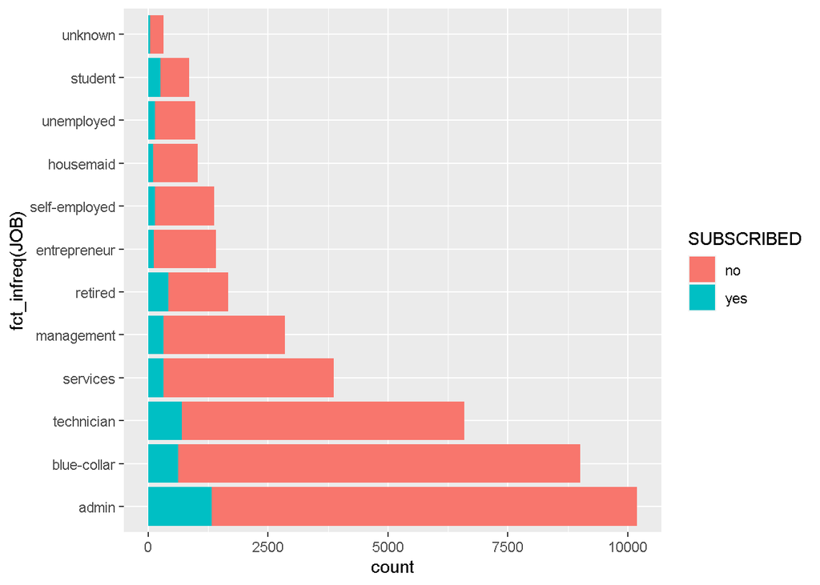

```r
ggplot(marketing, aes(x=fct_infreq(JOB), fill = SUBSCRIBED)) + geom_bar() + coord_flip()
```

As variáveis Admin, blue-collar e technician são as 3 maiores da categoria em valores abolutos.

A variavel admin possui mais clientes que aderiram ao serviço .

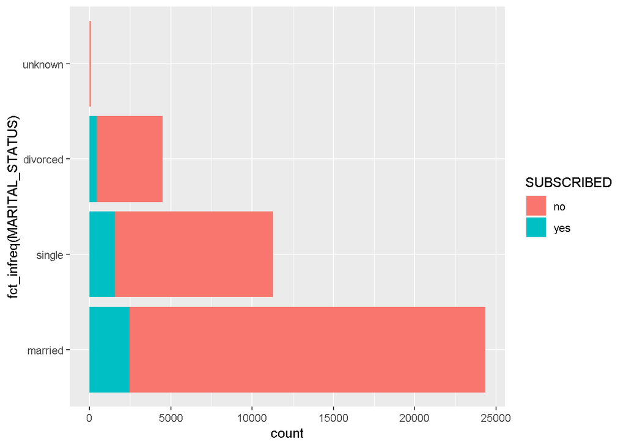

```r
ggplot(marketing, aes(x=fct_infreq(MARITAL_STATUS), fill = SUBSCRIBED)) + geom_bar() + coord_flip()
```

A variável married possui mais observações que as demais em valores relativos.

A variavel single possui mais inscritos, porém em valores absolutos married possui mais inscritos

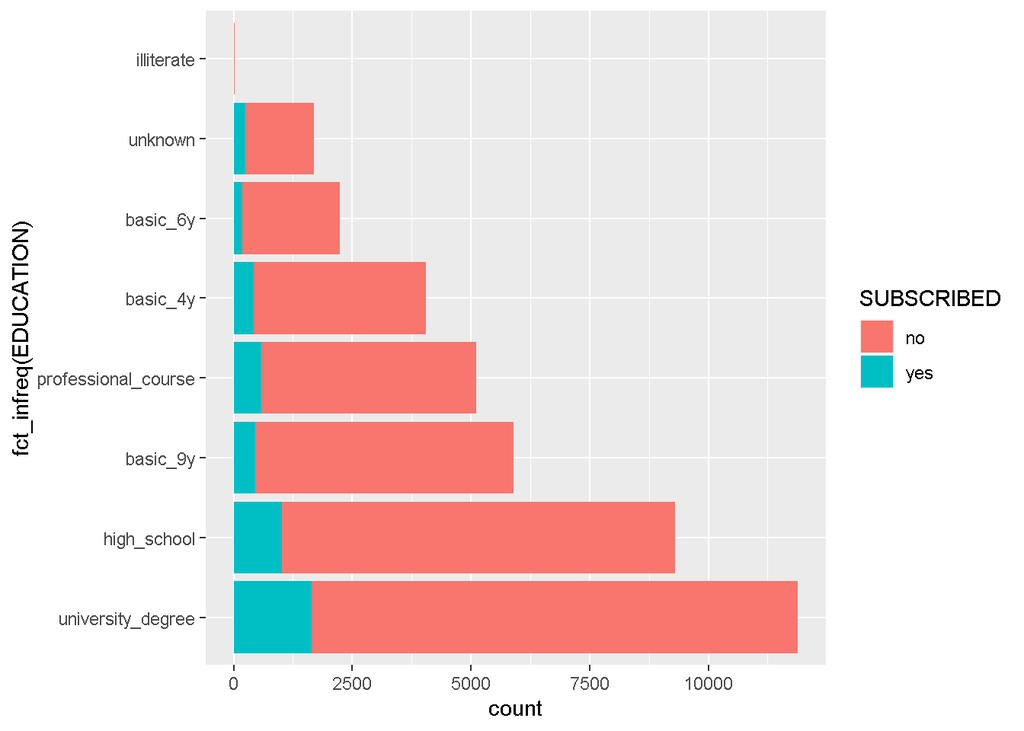

```r
ggplot(marketing, aes(x=fct_infreq(EDUCATION), fill = SUBSCRIBED)) + geom_bar() + coord_flip()
```

A maior parte dos clientes da base possui university_degree e high_school

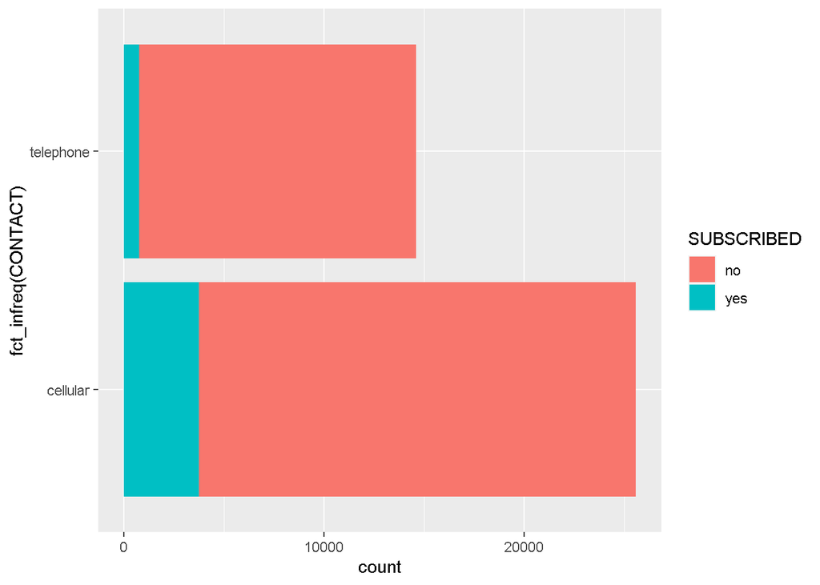

```r
ggplot(marketing, aes(x=fct_infreq(CONTACT), fill = SUBSCRIBED)) + geom_bar() + coord_flip()
```

A maior parte dos contatos é feito por celular

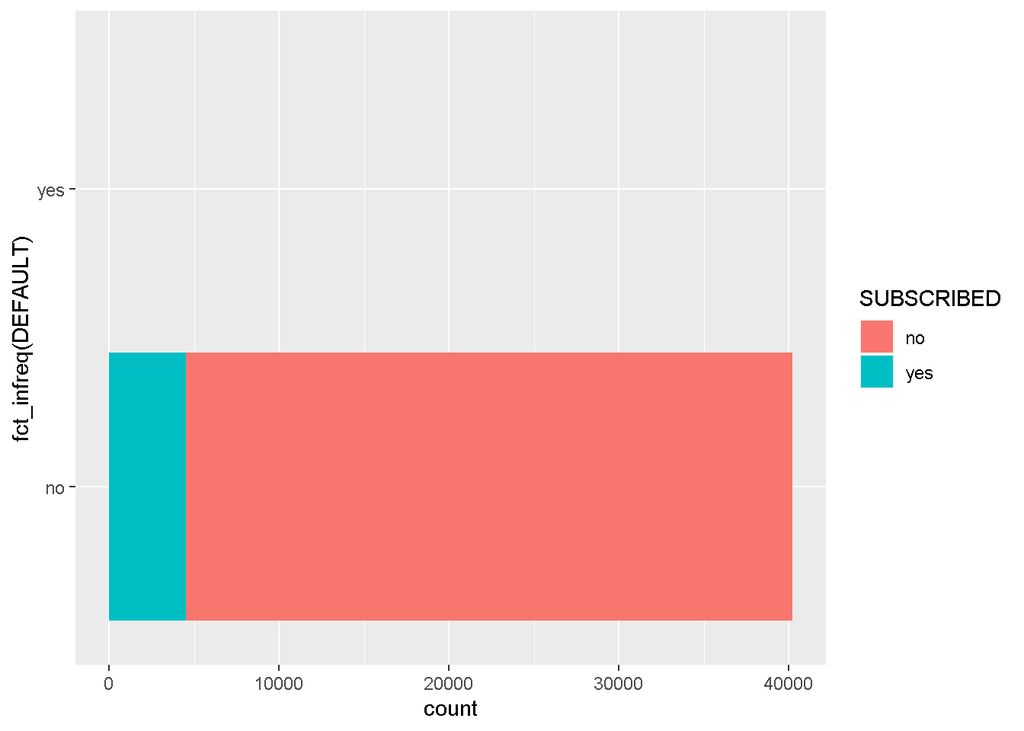

```r
ggplot(marketing, aes(x=fct_infreq(DEFAULT), fill = SUBSCRIBED)) + geom_bar() + coord_flip()
```

Praticamente nenhum cliente possui contas atrasadas.

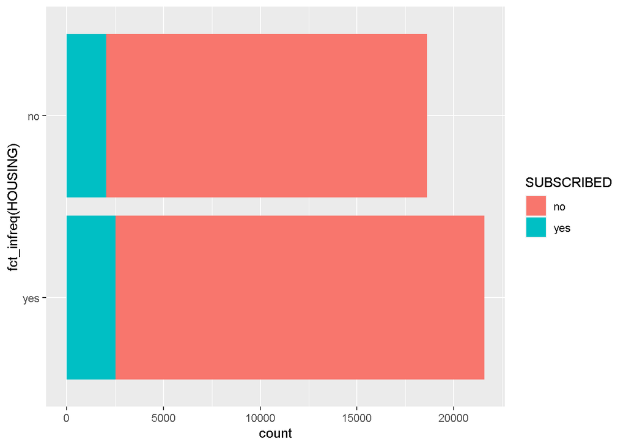

```r
ggplot(marketing, aes(x=fct_infreq(HOUSING), fill = SUBSCRIBED)) + geom_bar() + coord_flip()
```

Existe um numero equilibrado entre quem tem e quem não tem hipoteca, e também entre quem aderiu ou não ao servico.

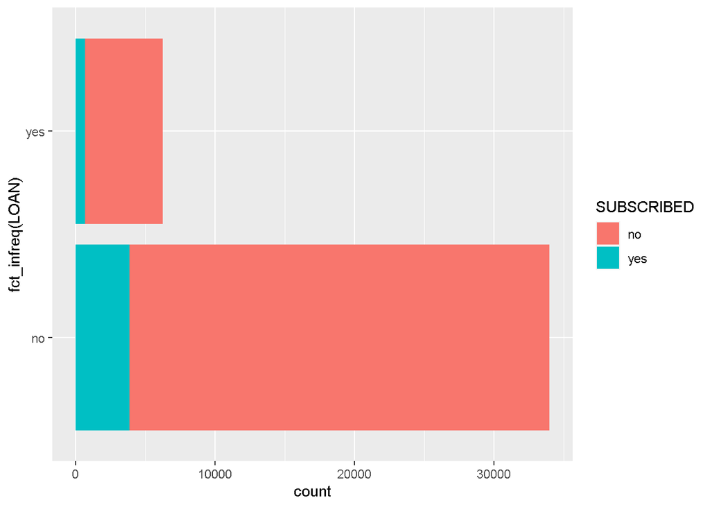

```r
ggplot(marketing, aes(x=fct_infreq(LOAN), fill = SUBSCRIBED)) + geom_bar() + coord_flip()
```

A maior parte não possui empréstimo pessoal.

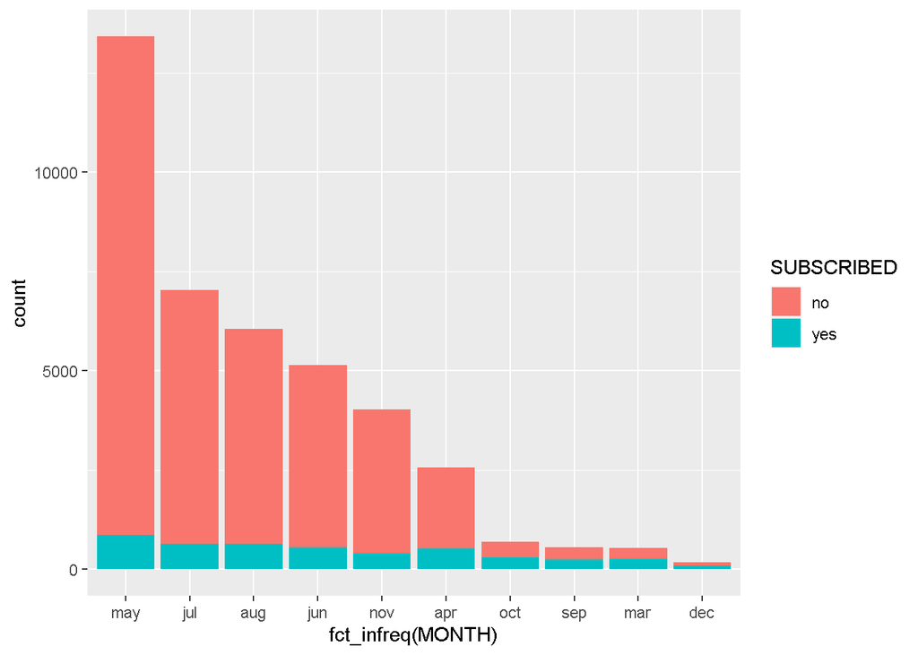

```r
ggplot(marketing, aes(x=fct_infreq(MONTH), fill = SUBSCRIBED)) + geom_bar()
```

A maior parte dos potenciais clientes foram atingidos pelas campanhas em maio, julho e agosto.

O mês com mais subscrição do serviço foi Maio, em valores absolutos.

## Plotando as variáveis discretas

Parece que as campanhas com maior duração conseguiram mais subscrições do serviço.

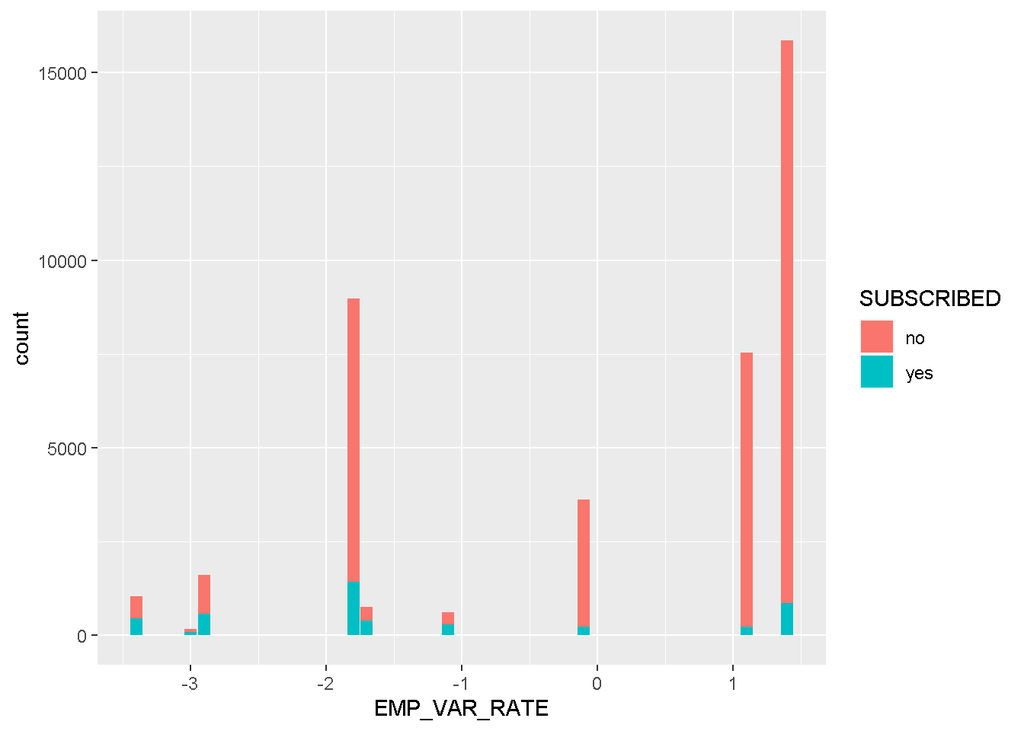

```r
ggplot(marketing, aes(x=EMP_VAR_RATE, fill = SUBSCRIBED)) + geom_bar()
```

### Tratamento de Outliers

#### AGE

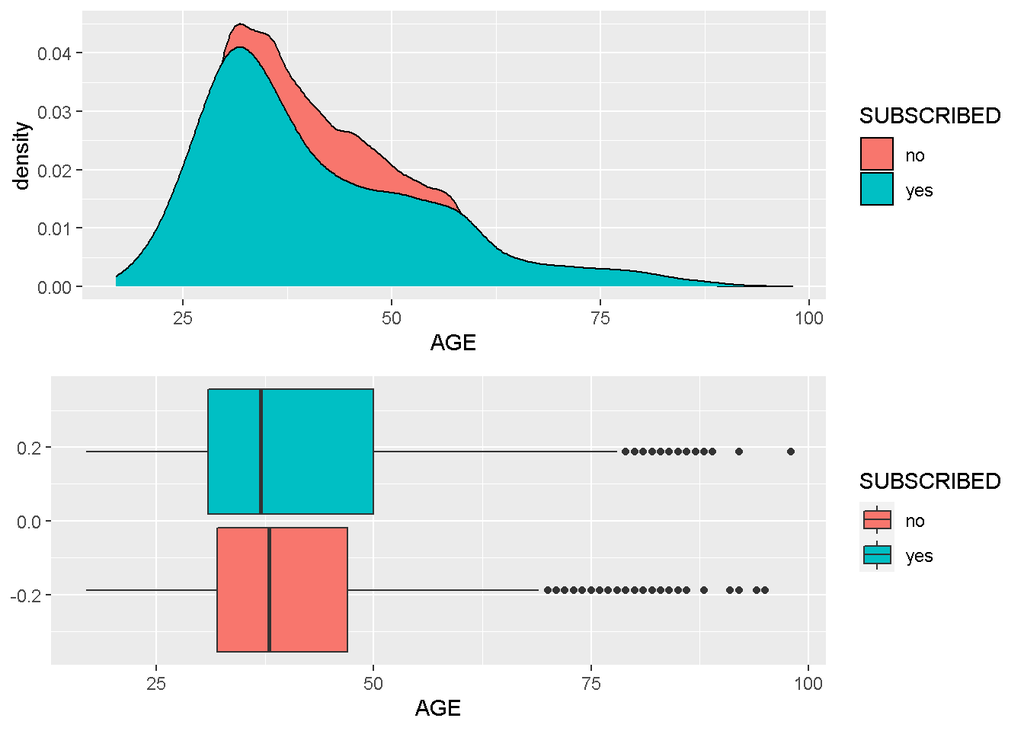

```r
a1 <- ggplot(marketing, aes(x=AGE, fill = SUBSCRIBED)) + geom_density()
a2 <- ggplot(marketing, aes(x=AGE, fill = SUBSCRIBED)) + geom_boxplot()
grid.arrange(a1,a2)
```

A idade dos clientes se concentra entre 30 e 50 anos. Portanto, os clientes mais novos aderiram mais ao seviço que os mais velhos.

Nota-se a presença de outliers em torno de 75 anos para cima. Porém, de acordo com o gráfico de densidade acima, pessoas com mais de 75 anos também aderiram ao serviço. Por isso não foram retirados estes outliers da base.

#### DURATION

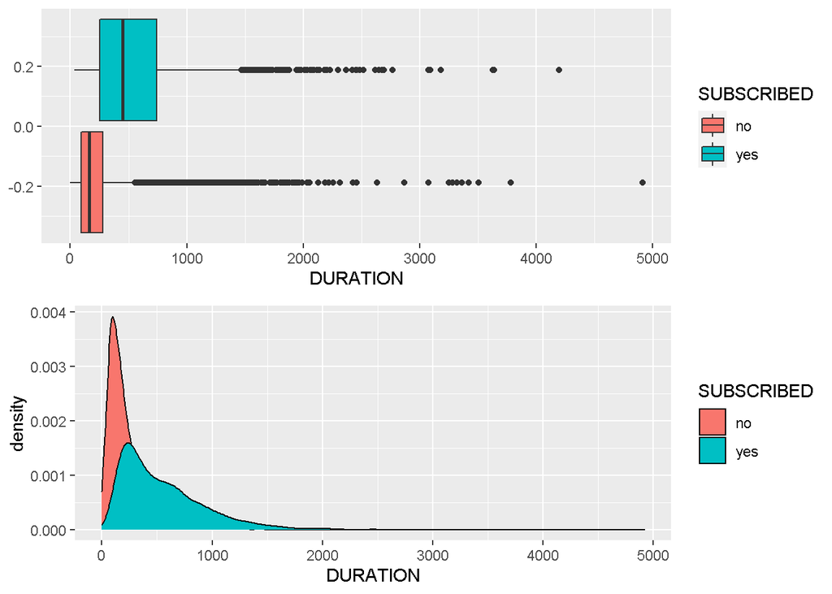

```r
p1 <- ggplot(marketing, aes(x=DURATION, fill = SUBSCRIBED)) + geom_boxplot()
p2 <- ggplot(marketing, aes(x=DURATION, fill = SUBSCRIBED)) + geom_density()
grid.arrange(p1, p2)
```

Apesar de existirem outliers, as campanhas com maior duração também apresentaram significativa aderência ao servico de acordo com o grá fico de densidade, por isso não serão retirados da base.

### POUTCOME (Resultado da Última Campanha)

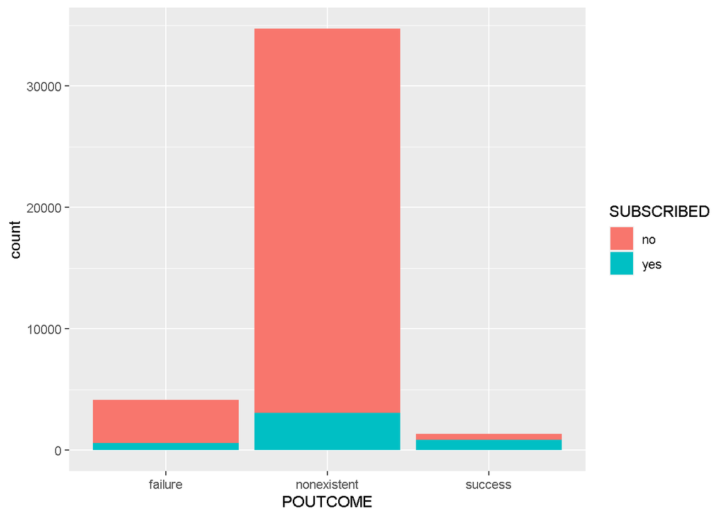

```r
ggplot(marketing, aes(x=POUTCOME, fill = SUBSCRIBED)) + geom_bar()
```

### Obtendo os valores numéricos para cada grupo de categorias sumarizando por aderência

#### Variável POUTCOME

```r
marketing %>% group_by(POUTCOME) %>% summarise(soma = sum(SUBSCRIBED=="yes")) %>% arrange(desc(soma))
```

```
## # A tibble: 3 x 2
##   POUTCOME     soma
##   <fct>       <int>
## 1 nonexistent  3078
## 2 success       873
## 3 failure       582
```

```r
marketing %>% group_by(POUTCOME) %>% summarise(soma = sum(SUBSCRIBED=="no")) %>% arrange(desc(soma))
```

```
## # A tibble: 3 x 2
##   POUTCOME     soma
##   <fct>       <int>
## 1 nonexistent 31634
## 2 failure      3559
## 3 success       472
```

Entre as campanhas que foram um sucesso, ocorreram 65% de subscrições. Entre as campanhas que foram falharam, ocorreram 14% de subscrições.

#### Variável MARITAL_STATUS

```r
marketing %>% group_by(MARITAL_STATUS) %>% summarise(soma = sum(SUBSCRIBED=="yes")) %>% arrange(desc(soma))
```

```
## # A tibble: 4 x 2
##   MARITAL_STATUS  soma
##   <fct>          <int>
## 1 married         2472
## 2 single          1581
## 3 divorced         468
## 4 unknown           12
```

```r
marketing %>% group_by(MARITAL_STATUS) %>% summarise(soma = sum(SUBSCRIBED=="no")) %>% arrange(desc(soma))
```

```
## # A tibble: 4 x 2
##   MARITAL_STATUS  soma
##   <fct>          <int>
## 1 married        21868
## 2 single          9707
## 3 divorced        4023
## 4 unknown           67
```

#### Variável JOB

```r
marketing %>% group_by(JOB) %>% summarise(soma = sum(SUBSCRIBED=="yes")) %>% arrange(desc(soma))
```

```
## # A tibble: 12 x 2
##    JOB            soma
##    <fct>         <int>
##  1 admin          1323
##  2 technician      709
##  3 blue-collar     622
##  4 retired         424
##  5 management      324
##  6 services        316
##  7 student         264
##  8 self-employed   147
##  9 unemployed      143
## 10 entrepreneur    121
## 11 housemaid       103
## 12 unknown          37
```

```r
marketing %>% group_by(JOB) %>% summarise(soma = sum(SUBSCRIBED=="no")) %>% arrange(desc(soma))
```

```
## # A tibble: 12 x 2
##    JOB            soma
##    <fct>         <int>
##  1 admin          8872
##  2 blue-collar    8392
##  3 technician     5887
##  4 services       3552
##  5 management     2529
##  6 entrepreneur   1299
##  7 retired        1252
##  8 self-employed  1234
##  9 housemaid       928
## 10 unemployed      844
## 11 student         588
## 12 unknown         288
```

Entre as pessoas de cargo admin, ocorreram 13% de subscrições.

```r
marketing %>% group_by(EDUCATION) %>% summarise(soma = sum(SUBSCRIBED=="yes")) %>% arrange(desc(soma))
```

```
## # A tibble: 8 x 2
##   EDUCATION            soma
##   <ord>               <int>
## 1 university_degree    1636
## 2 high_school          1010
## 3 professional_course   579
## 4 basic_9y              460
## 5 basic_4y              417
## 6 unknown               246
## 7 basic_6y              181
## 8 illiterate              4
```

#### Variável EDUCATION

```r
marketing %>% group_by(EDUCATION) %>% summarise(soma = sum(SUBSCRIBED=="no")) %>% arrange(desc(soma))
```

```
## # A tibble: 8 x 2
##   EDUCATION            soma
##   <ord>               <int>
## 1 university_degree   10255
## 2 high_school          8285
## 3 basic_9y             5434
## 4 professional_course  4539
## 5 basic_4y             3642
## 6 basic_6y             2051
## 7 unknown              1445
## 8 illiterate             14
```

Entre as pessoas com university_degree, ocorreram 14% de subscrições.

#### Variável HOUSING

```r
marketing %>% group_by(HOUSING) %>% summarise(soma = sum(SUBSCRIBED=="yes")) %>% arrange(desc(soma))
```

```
## # A tibble: 2 x 2
##   HOUSING  soma
##   <fct>   <int>
## 1 yes      2507
## 2 no       2026
```

```r
marketing %>% group_by(HOUSING) %>% summarise(soma = sum(SUBSCRIBED=="no")) %>% arrange(desc(soma))
```

```
## # A tibble: 2 x 2
##   HOUSING  soma
##   <fct>   <int>
## 1 yes     19069
## 2 no      16596
```

Entre as pessoas com HOUSING (hipoteca), ocorreram 12% de subscrições.

#### Variável DEFAULT

```r
marketing %>% group_by(DEFAULT) %>% summarise(soma = sum(SUBSCRIBED=="yes")) %>% arrange(desc(soma))
```

```
## # A tibble: 2 x 2
##   DEFAULT  soma
##   <chr>   <int>
## 1 no       4533
## 2 yes         0
```

```r
marketing %>% group_by(DEFAULT) %>% summarise(soma = sum(SUBSCRIBED=="no")) %>% arrange(desc(soma))
```

```
## # A tibble: 2 x 2
##   DEFAULT  soma
##   <chr>   <int>
## 1 no      35662
## 2 yes         3
```

Entre as pessoas sem DEFAULT (contas atrasadas), ocorreram 11% de subscrições. Entre as pessoas com DEFAULT (contas atrasadas), não ocorreu nenhuma subscrição.

#### Variável CONTACT

```r
marketing %>% group_by(CONTACT) %>% summarise(soma = sum(SUBSCRIBED=="yes")) %>% arrange(desc(soma))
```

```
## # A tibble: 2 x 2
##   CONTACT    soma
##   <fct>     <int>
## 1 cellular   3761
## 2 telephone   772
```

```r
marketing %>% group_by(CONTACT) %>% summarise(soma = sum(SUBSCRIBED=="no")) %>% arrange(desc(soma))
```

```
## # A tibble: 2 x 2
##   CONTACT    soma
##   <fct>     <int>
## 1 cellular  21822
## 2 telephone 13843
```

Entre as pessoas que entraram em contato por celular, ocorreram 15% de subscrições. Entre as pessoas que entraram em contato por telefone, ocorreram 5% de subscrições.

## Preparação da base de dados para modelagem

### Dividindo em Base de Treino e teste

```r
set.seed(314)
trainIndex <- createDataPartition(marketing$SUBSCRIBED, p = .7, list = FALSE)
dfTrain <- marketing[ trainIndex,]
dfTest  <- marketing[-trainIndex,]
dim(dfTest)
```

```
## [1] 12058    19
```

### Criando base de teste com a variavel resposta no formato numerico para calcular ROC e AUC

```r
dfTest_num <- dfTest
dfTest_num$SUBSCRIBED <- ifelse(dfTest$SUBSCRIBED == "yes",1,0)
```

## Modelagem de dados

### Regressao Logística

```r
set.seed(314)
tc <- trainControl(method="repeatedcv", number=10, savePredictions = T, summaryFunction = twoClassSummary, classProbs = TRUE)
model_glm1 <- caret::train(SUBSCRIBED~., data = dfTrain, method = "glm", metric="ROC", trControl= tc, control = list(maxit = 50))
model_glm1[4]
```

```
## $results
##   parameter       ROC      Sens      Spec       ROCSD     SensSD     SpecSD
## 1      none 0.9345209 0.9728029 0.4209214 0.006094818 0.00235551 0.03231347
```

```r
summary(model_glm1)
```

```
##
## Call:
## NULL
##
## Deviance Residuals:
##     Min       1Q   Median       3Q      Max
## -5.6651  -0.3002  -0.1850  -0.1327   3.2462
##
## Coefficients: (2 not defined because of singularities)
##                         Estimate Std. Error z value Pr(>|z|)
## (Intercept)           -1.157e+02  6.665e+00 -17.356  < 2e-16 ***
## AGE                   -3.869e-03  2.925e-03  -1.323 0.185904
## `JOBblue-collar`      -2.493e-01  9.664e-02  -2.580 0.009891 **
## JOBentrepreneur       -1.918e-01  1.551e-01  -1.236 0.216278
## JOBhousemaid          -8.065e-02  1.831e-01  -0.440 0.659683
## JOBmanagement         -6.685e-02  1.026e-01  -0.651 0.514767
## JOBretired             4.457e-01  1.294e-01   3.443 0.000575 ***
## `JOBself-employed`    -5.825e-02  1.407e-01  -0.414 0.678916
## JOBservices           -1.004e-01  1.034e-01  -0.971 0.331619
## JOBstudent             1.007e-01  1.351e-01   0.745 0.456076
## JOBtechnician         -9.074e-03  8.600e-02  -0.106 0.915979
## JOBunemployed          1.108e-01  1.520e-01   0.729 0.466264
## JOBunknown             7.617e-02  2.704e-01   0.282 0.778146
## MARITAL_STATUSmarried -5.620e-02  8.186e-02  -0.687 0.492369
## MARITAL_STATUSsingle  -5.592e-02  9.389e-02  -0.596 0.551418
## MARITAL_STATUSunknown  8.579e-02  4.946e-01   0.173 0.862295
## EDUCATION.L           -4.455e-01  3.260e-01  -1.366 0.171847
## EDUCATION.Q            2.705e-01  1.133e-01   2.387 0.016996 *
## EDUCATION.C            3.927e-01  2.638e-01   1.489 0.136586
## `EDUCATION^4`         -6.023e-01  4.339e-01  -1.388 0.165090
## `EDUCATION^5`          6.818e-01  4.079e-01   1.671 0.094641 .
## `EDUCATION^6`         -5.232e-01  2.625e-01  -1.993 0.046208 *
## `EDUCATION^7`          2.626e-01  1.321e-01   1.988 0.046783 *
## DEFAULTyes            -7.239e+00  1.135e+02  -0.064 0.949166
## HOUSINGunknown                NA         NA      NA       NA
## HOUSINGyes            -2.795e-02  4.951e-02  -0.565 0.572381
## LOANunknown                   NA         NA      NA       NA
## LOANyes               -2.697e-02  6.885e-02  -0.392 0.695273
## CONTACTtelephone      -4.926e-01  8.442e-02  -5.835 5.37e-09 ***
## MONTHaug               5.483e-01  1.258e-01   4.358 1.31e-05 ***
```

[output cut: 16 more lines]

```
## POUTCOMEnonexistent    5.684e-01  1.139e-01   4.991 6.00e-07 ***
## POUTCOMEsuccess        1.735e+00  1.329e-01  13.049  < 2e-16 ***
## EMP_VAR_RATE          -9.731e-01  2.979e-02 -32.663  < 2e-16 ***
## CONS_PRICE_IDX         1.204e+00  7.203e-02  16.710  < 2e-16 ***
## CONS_CONF_IDX          2.658e-02  6.261e-03   4.246 2.18e-05 ***
## ---
## Signif. codes:  0 '***' 0.001 '**' 0.01 '*' 0.05 '.' 0.1 ' ' 1
##
## (Dispersion parameter for binomial family taken to be 1)
##
##     Null deviance: 19828  on 28139  degrees of freedom
## Residual deviance: 11677  on 28091  degrees of freedom
## AIC: 11775
##
## Number of Fisher Scoring iterations: 10
```

```r
model_glm2 <- caret::train(SUBSCRIBED~MONTH+EDUCATION+JOB+CONTACT+DAY_OF_WEEK+DURATION+CAMPAIGN+POUTCOME+EMP_VAR_RATE+ CONS_PRICE_IDX+CONS_CONF_IDX, data = dfTrain, method = "glm", metric="ROC", trControl= tc, control = list(maxit = 50))
model_glm2[4]
```

```
## $results
##   parameter       ROC      Sens      Spec       ROCSD      SensSD     SpecSD
## 1      none 0.9343589 0.9724826 0.4247079 0.008473777 0.003126126 0.04618674
```

```r
summary(model_glm2)
```

```
##
## Call:
## NULL
##
## Deviance Residuals:
##     Min       1Q   Median       3Q      Max
## -5.6619  -0.3010  -0.1850  -0.1332   3.2472
##
## Coefficients:
##                       Estimate Std. Error z value Pr(>|z|)
## (Intercept)         -1.185e+02  6.401e+00 -18.519  < 2e-16 ***
## MONTHaug             5.723e-01  1.250e-01   4.578 4.70e-06 ***
## MONTHdec             1.944e-01  2.375e-01   0.819  0.41303
## MONTHjul             2.748e-01  1.129e-01   2.434  0.01494 *
## MONTHjun             7.291e-02  1.084e-01   0.672  0.50135
## MONTHmar             1.786e+00  1.413e-01  12.638  < 2e-16 ***
## MONTHmay            -5.499e-01  9.064e-02  -6.066 1.31e-09 ***
## MONTHnov            -2.268e-01  1.160e-01  -1.956  0.05045 .
## MONTHoct             8.327e-02  1.472e-01   0.566  0.57169
## MONTHsep             1.304e-01  1.578e-01   0.826  0.40887
## EDUCATION.L         -4.307e-01  3.257e-01  -1.322  0.18608
## EDUCATION.Q          2.727e-01  1.131e-01   2.412  0.01588 *
## EDUCATION.C          3.862e-01  2.638e-01   1.464  0.14325
## `EDUCATION^4`       -6.017e-01  4.339e-01  -1.387  0.16555
## `EDUCATION^5`        6.939e-01  4.080e-01   1.701  0.08896 .
## `EDUCATION^6`       -5.274e-01  2.625e-01  -2.009  0.04455 *
## `EDUCATION^7`        2.701e-01  1.320e-01   2.046  0.04071 *
## `JOBblue-collar`    -2.475e-01  9.622e-02  -2.572  0.01011 *
## JOBentrepreneur     -2.035e-01  1.544e-01  -1.318  0.18748
## JOBhousemaid        -1.069e-01  1.824e-01  -0.586  0.55762
## JOBmanagement       -8.074e-02  1.014e-01  -0.796  0.42592
## JOBretired           3.547e-01  1.104e-01   3.212  0.00132 **
## `JOBself-employed`  -6.293e-02  1.406e-01  -0.448  0.65450
## JOBservices         -9.706e-02  1.032e-01  -0.941  0.34694
## JOBstudent           1.575e-01  1.277e-01   1.233  0.21763
## JOBtechnician       -5.239e-03  8.589e-02  -0.061  0.95136
## JOBunemployed        1.013e-01  1.518e-01   0.667  0.50478
## JOBunknown           4.797e-02  2.702e-01   0.178  0.85908
## CONTACTtelephone    -4.966e-01  8.418e-02  -5.900 3.64e-09 ***
## DAY_OF_WEEKmon      -1.121e-01  8.000e-02  -1.402  0.16103
## DAY_OF_WEEKthu       6.858e-02  7.733e-02   0.887  0.37522
## DAY_OF_WEEKtue       1.196e-01  7.995e-02   1.497  0.13452
## DAY_OF_WEEKwed       2.065e-01  7.976e-02   2.589  0.00962 **
## DURATION             4.679e-03  8.930e-05  52.400  < 2e-16 ***
## CAMPAIGN            -3.390e-02  1.384e-02  -2.450  0.01429 *
## POUTCOMEnonexistent  4.454e-01  7.441e-02   5.986 2.15e-09 ***
## POUTCOMEsuccess      1.853e+00  1.024e-01  18.092  < 2e-16 ***
## EMP_VAR_RATE        -9.809e-01  2.918e-02 -33.619  < 2e-16 ***
## CONS_PRICE_IDX       1.233e+00  6.892e-02  17.887  < 2e-16 ***
## CONS_CONF_IDX        2.628e-02  6.228e-03   4.220 2.44e-05 ***
## ---
## Signif. codes:  0 '***' 0.001 '**' 0.01 '*' 0.05 '.' 0.1 ' ' 1
##
## (Dispersion parameter for binomial family taken to be 1)
##
##     Null deviance: 19828  on 28139  degrees of freedom
## Residual deviance: 11683  on 28100  degrees of freedom
## AIC: 11763
##
## Number of Fisher Scoring iterations: 6
```

## Predição

```r
dfProbs <- predict(model_glm2,dfTest,type="prob", SCALE=FALSE)
```

## Gráfico das probabilidades da predição

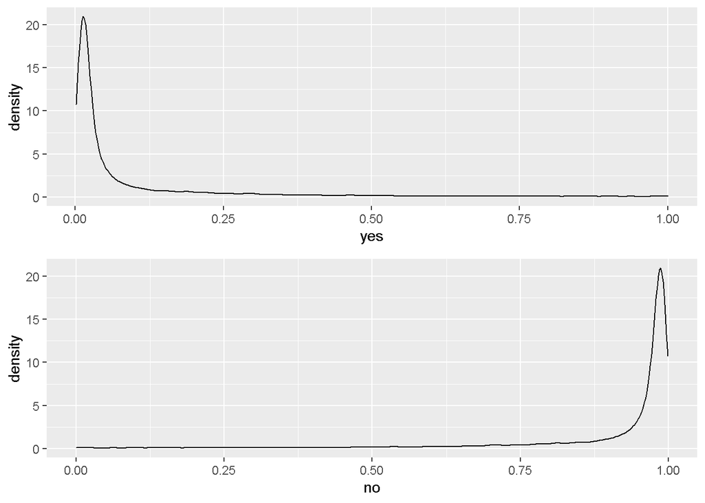

```r
pp1 <- ggplot(dfProbs, aes(x=yes)) + geom_density()
pp2 <- ggplot(dfProbs, aes(x=no)) + geom_density() # cutoff proximo de 0.9
grid.arrange(pp1,pp2)
```

## Testando com limite de 0.85

```r
dfPref_85 <- ifelse(dfProbs[1] > 0.85, "no", "yes")
dfPref_85 <- as.factor(dfPref_85)
caret::confusionMatrix(dfPref_85, as.factor(dfTest$SUBSCRIBED), positive = "yes")
```

```
## Confusion Matrix and Statistics
##
##           Reference
## Prediction   no  yes
##        no  9402  264
##        yes 1297 1095
##
##                Accuracy : 0.8705
##                  95% CI : (0.8644, 0.8765)
##     No Information Rate : 0.8873
##     P-Value [Acc > NIR] : 1
##
##                   Kappa : 0.514
##
##  Mcnemar's Test P-Value : <2e-16
##
##             Sensitivity : 0.80574
##             Specificity : 0.87877
##          Pos Pred Value : 0.45778
##          Neg Pred Value : 0.97269
##              Prevalence : 0.11271
##          Detection Rate : 0.09081
##    Detection Prevalence : 0.19837
##       Balanced Accuracy : 0.84226
##
##        'Positive' Class : yes
##
```

## Calculando ROC e AUC

```r
dfPref_num_85 <- ifelse(dfPref_85 == "yes",1,0)

roc_85 <- pROC::roc(dfTest_num$SUBSCRIBED, dfPref_num_85)
roc_85
```

```
##
## Call:
## roc.default(response = dfTest_num$SUBSCRIBED, predictor = dfPref_num_85)
##
## Data: dfPref_num_85 in 10699 controls (dfTest_num$SUBSCRIBED 0) < 1359 cases (dfTest_num$SUBSCRIBED 1).
## Area under the curve: 0.8423
```

## Curva ROC

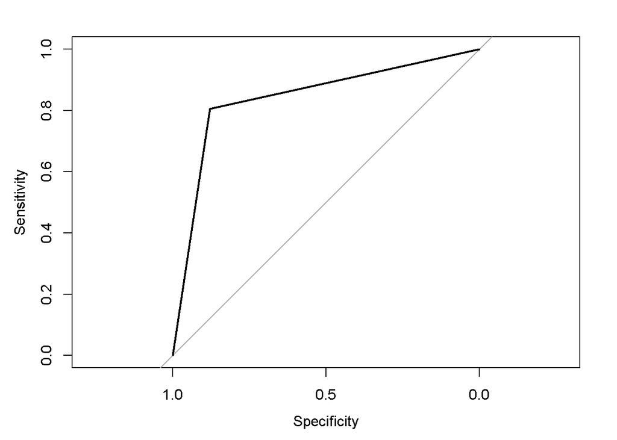

```r
plot(roc_85)
```

## Testando com limite de 0.9

```r
dfPref_90 <- ifelse(dfProbs[1] > 0.9, "no", "yes")
dfPref_90 <- as.factor(dfPref_90)
caret::confusionMatrix(dfPref_90, as.factor(dfTest$SUBSCRIBED), positive = "yes")
```

```
## Confusion Matrix and Statistics
##
##           Reference
## Prediction   no  yes
##        no  8983  161
##        yes 1716 1198
##
##                Accuracy : 0.8443
##                  95% CI : (0.8377, 0.8508)
##     No Information Rate : 0.8873
##     P-Value [Acc > NIR] : 1
##
##                   Kappa : 0.4809
##
##  Mcnemar's Test P-Value : <2e-16
##
##             Sensitivity : 0.88153
##             Specificity : 0.83961
##          Pos Pred Value : 0.41112
##          Neg Pred Value : 0.98239
##              Prevalence : 0.11271
##          Detection Rate : 0.09935
##    Detection Prevalence : 0.24167
##       Balanced Accuracy : 0.86057
##
##        'Positive' Class : yes
##
```

## Comparação dos Cutoffs (limites de probabilidas da variável resposta)

### Cutoff 0.85

Prediction no yes

[output not shown]

### cutoff 0.9

Prediction no yes

[output not shown]

Se o custo de rodar a campanha for alto, será escolhido um modelo que erra menos negativos

Se o custo de rodar a campanha for baixo, será escolhido um modelo que acerta mais positivos

```r
dfPref_num_90 <- ifelse(dfPref_90== "yes",1,0)
roc_90 <- pROC::roc(dfTest_num$SUBSCRIBED, dfPref_num_90)
roc_90
```

```
##
## Call:
## roc.default(response = dfTest_num$SUBSCRIBED, predictor = dfPref_num_90)
##
## Data: dfPref_num_90 in 10699 controls (dfTest_num$SUBSCRIBED 0) < 1359 cases (dfTest_num$SUBSCRIBED 1).
## Area under the curve: 0.8606
```

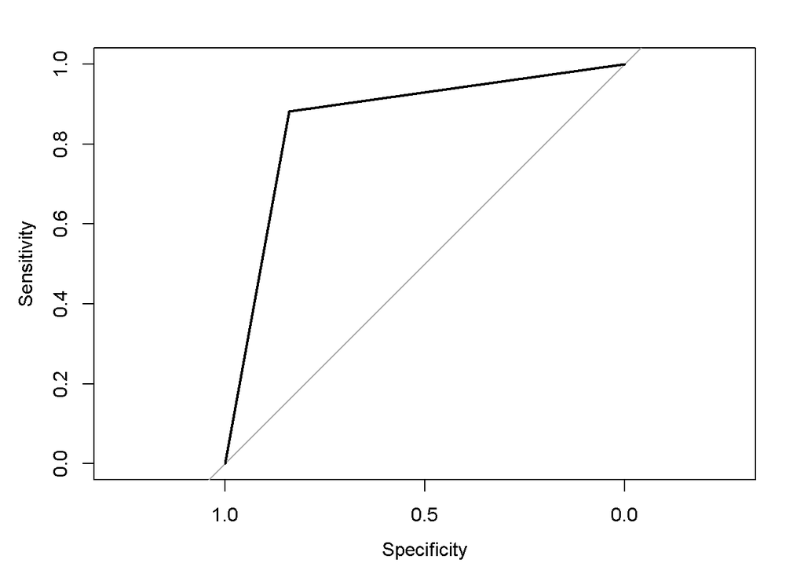

```r
plot(roc_90)
```

## Árvore de Decisão

### Modelo TreeBag

```r
set.seed(314)
tc <- trainControl(method="repeatedcv", number=10, savePredictions = T, classProbs = TRUE)
modeltree <- train(SUBSCRIBED~., data = dfTrain, method = "treebag", trControl= tc, num_trees = 100)
pred_tree <- predict(modeltree,dfTest)

caret::confusionMatrix(data=pred_tree, dfTest$SUBSCRIBED, positive="yes")
```

```
## Confusion Matrix and Statistics
##
##           Reference
## Prediction    no   yes
##        no  10257   686
##        yes   442   673
##
##                Accuracy : 0.9065
##                  95% CI : (0.9011, 0.9116)
##     No Information Rate : 0.8873
##     P-Value [Acc > NIR] : 4.840e-12
##
##                   Kappa : 0.4925
##
##  Mcnemar's Test P-Value : 4.648e-13
##
##             Sensitivity : 0.49522
##             Specificity : 0.95869
##          Pos Pred Value : 0.60359
##          Neg Pred Value : 0.93731
##              Prevalence : 0.11271
##          Detection Rate : 0.05581
##    Detection Prevalence : 0.09247
##       Balanced Accuracy : 0.72695
##
##        'Positive' Class : yes
##
```

```r
modeltree[4]
```

```
## $results
##   parameter  Accuracy     Kappa  AccuracySD    KappaSD
## 1      none 0.9072848 0.5090531 0.004410102 0.02310485
```

#### Configurações para otimizar o processamento

```r
library(doParallel)
registerDoParallel(4)
getDoParWorkers()
```

```
## [1] 4
```

```r
memory.limit (9999999999)
```

```
## [1] 1e+10
```

### Modelo C.5tree

```r
set.seed(314)
mtry <- sqrt(ncol(dfTrain))
mtry <- 3
tunegrid <- expand.grid(mtry=3)

modelc5 <- train(SUBSCRIBED~., data = dfTrain, method = "C5.0Tree", trControl= tc)
pred_c5 <- predict(modelc5,dfTest)
caret::confusionMatrix(data=pred_c5, dfTest$SUBSCRIBED, positive="yes")
```

```
## Confusion Matrix and Statistics
##
##           Reference
## Prediction    no   yes
##        no  10404   800
##        yes   295   559
##
##                Accuracy : 0.9092
##                  95% CI : (0.9039, 0.9143)
##     No Information Rate : 0.8873
##     P-Value [Acc > NIR] : 2.669e-15
##
##                   Kappa : 0.4581
##
##  Mcnemar's Test P-Value : < 2.2e-16
##
##             Sensitivity : 0.41133
##             Specificity : 0.97243
##          Pos Pred Value : 0.65457
##          Neg Pred Value : 0.92860
##              Prevalence : 0.11271
##          Detection Rate : 0.04636
##    Detection Prevalence : 0.07082
##       Balanced Accuracy : 0.69188
##
##        'Positive' Class : yes
##
```

### Calculando ROC e AUC

```r
pred_c5_num <- ifelse(pred_c5 == "yes",1,0)
roc <- pROC::roc(dfTest_num$SUBSCRIBED, pred_c5_num)
roc
```

```
##
## Call:
## roc.default(response = dfTest_num$SUBSCRIBED, predictor = pred_c5_num)
##
## Data: pred_c5_num in 10699 controls (dfTest_num$SUBSCRIBED 0) < 1359 cases (dfTest_num$SUBSCRIBED 1).
## Area under the curve: 0.6919
```

### Gráfico ROC

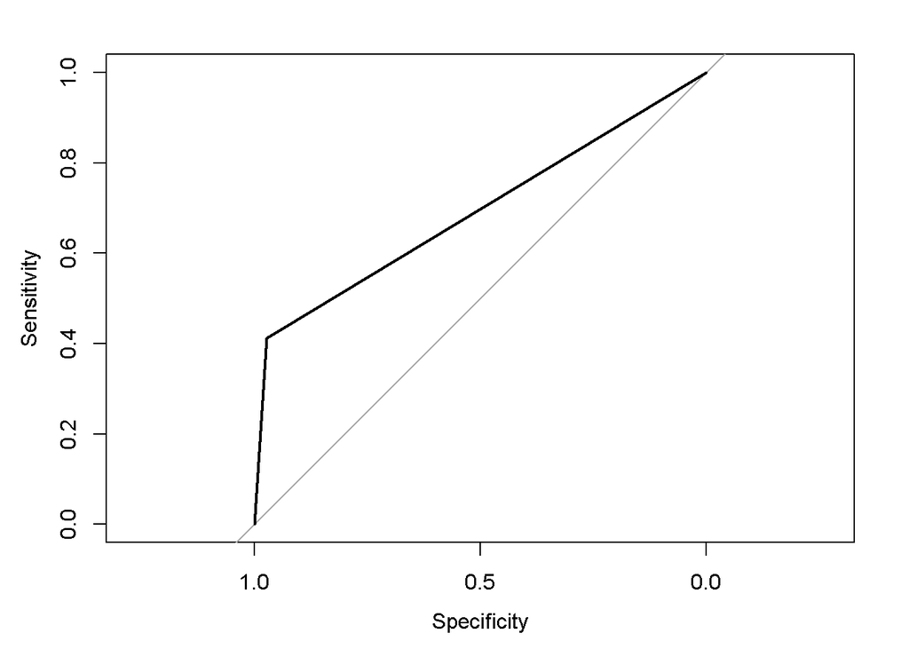

```r
plot(roc)
```

## Modelo SVM

### SVM Linear

#### Controle da funcao train para o modelo SVM linear

```r
tcsvm <- trainControl(method="repeatedcv", number=5, savePredictions = T, classProbs = TRUE)
tcsvm <- trainControl(savePredictions = T, classProbs = TRUE)
str(dfTrain)
```

```
## 'data.frame':    28140 obs. of  19 variables:
##  $ AGE           : int  56 57 37 40 56 45 59 41 25 41 ...
##  $ JOB           : Factor w/ 12 levels "admin","blue-collar",..: 4 8 8 1 8 8 1 2 8 2 ...
##  $ MARITAL_STATUS: Factor w/ 4 levels "divorced","married",..: 2 2 2 2 2 2 2 2 3 2 ...
##  $ EDUCATION     : Ord.factor w/ 8 levels "unknown"<"illiterate"<..: 3 6 6 4 6 5 7 1 6 1 ...
##  $ DEFAULT       : chr  "no" "no" "no" "no" ...
##  $ HOUSING       : Factor w/ 3 levels "no","unknown",..: 1 1 3 1 1 1 1 1 3 1 ...
##  $ LOAN          : Factor w/ 3 levels "no","unknown",..: 1 1 1 1 3 1 1 1 1 1 ...
##  $ CONTACT       : Factor w/ 2 levels "cellular","telephone": 2 2 2 2 2 2 2 2 2 2 ...
##  $ MONTH         : Factor w/ 10 levels "apr","aug","dec",..: 7 7 7 7 7 7 7 7 7 7 ...
##  $ DAY_OF_WEEK   : Factor w/ 5 levels "fri","mon","thu",..: 2 2 2 2 2 2 2 2 2 2 ...
##  $ DURATION      : int  261 149 226 151 307 198 139 217 50 55 ...
##  $ CAMPAIGN      : int  1 1 1 1 1 1 1 1 1 1 ...
##  $ PDAYS         : int  -1 -1 -1 -1 -1 -1 -1 -1 -1 -1 ...
##  $ PREVIOUS      : int  0 0 0 0 0 0 0 0 0 0 ...
##  $ POUTCOME      : Factor w/ 3 levels "failure","nonexistent",..: 2 2 2 2 2 2 2 2 2 2 ...
##  $ EMP_VAR_RATE  : num  1.1 1.1 1.1 1.1 1.1 1.1 1.1 1.1 1.1 1.1 ...
##  $ CONS_PRICE_IDX: num  94 94 94 94 94 ...
##  $ CONS_CONF_IDX : num  -36.4 -36.4 -36.4 -36.4 -36.4 -36.4 -36.4 -36.4 -36.4 -36.4 ...
##  $ SUBSCRIBED    : Factor w/ 2 levels "no","yes": 1 1 1 1 1 1 1 1 1 1 ...
```

```r
modelsvm <- train(SUBSCRIBED~MONTH+EDUCATION+JOB+ CONTACT+DAY_OF_WEEK+DURATION+CAMPAIGN+POUTCOME+EMP_VAR_RATE+ CONS_PRICE_IDX+CONS_CONF_IDX, data = dfTrain, method = "svmLinear", trControl= tcsvm, preProcess = c("center", "scale"))
summary(modelsvm)
```

```
## Length  Class   Mode
##      1   ksvm     S4
```

```r
modelsvm[4]
```

```
## $results
##   C  Accuracy     Kappa  AccuracySD    KappaSD
## 1 1 0.9055668 0.4119542 0.002485849 0.01976084
```

```r
predsvm <- predict(modelsvm,dfTest)
caret::confusionMatrix(predsvm, dfTest$SUBSCRIBED, positive="yes")
```

```
## Confusion Matrix and Statistics
##
##           Reference
## Prediction    no   yes
##        no  10452   907
##        yes   247   452
##
##                Accuracy : 0.9043
##                  95% CI : (0.8989, 0.9095)
##     No Information Rate : 0.8873
##     P-Value [Acc > NIR] : 8.537e-10
##
##                   Kappa : 0.3928
##
##  Mcnemar's Test P-Value : < 2.2e-16
##
##             Sensitivity : 0.33260
##             Specificity : 0.97691
##          Pos Pred Value : 0.64664
##          Neg Pred Value : 0.92015
##              Prevalence : 0.11271
##          Detection Rate : 0.03749
##    Detection Prevalence : 0.05797
##       Balanced Accuracy : 0.65476
##
##        'Positive' Class : yes
##
```

### Calculando ROC e AUC

```r
predsvm <- ifelse(predsvm == "yes",1,0)
roc <- pROC::roc(dfTest_num$SUBSCRIBED, predsvm)
roc
```

```
##
## Call:
## roc.default(response = dfTest_num$SUBSCRIBED, predictor = predsvm)
##
## Data: predsvm in 10699 controls (dfTest_num$SUBSCRIBED 0) < 1359 cases (dfTest_num$SUBSCRIBED 1).
## Area under the curve: 0.6548
```

### Gráfico ROC

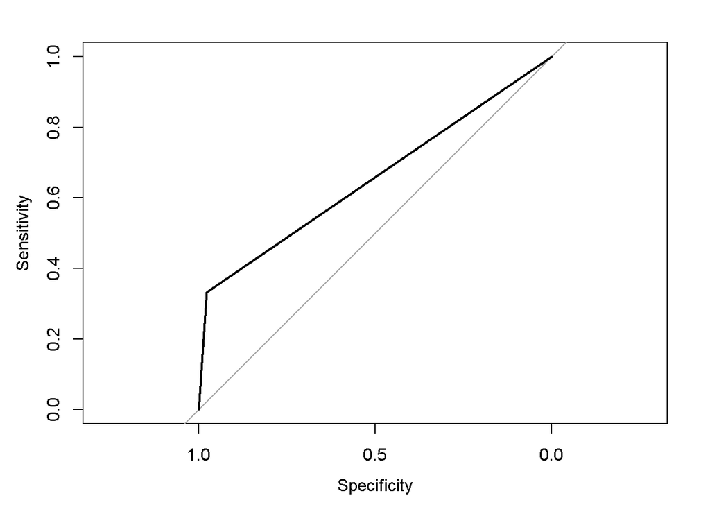

```r
plot(roc)
```

## Redes Neurais

### Inicializando h2o

```r
h2o.init()
```

### Transformando os dados processados em h2o

```r
str(marketing)
```

```
## 'data.frame':    40198 obs. of  19 variables:
##  $ AGE           : int  56 57 37 40 56 45 59 41 24 25 ...
##  $ JOB           : Factor w/ 12 levels "admin","blue-collar",..: 4 8 8 1 8 8 1 2 10 8 ...
##  $ MARITAL_STATUS: Factor w/ 4 levels "divorced","married",..: 2 2 2 2 2 2 2 2 3 3 ...
##  $ EDUCATION     : Ord.factor w/ 8 levels "unknown"<"illiterate"<..: 3 6 6 4 6 5 7 1 7 6 ...
##  $ DEFAULT       : chr  "no" "no" "no" "no" ...
##  $ HOUSING       : Factor w/ 3 levels "no","unknown",..: 1 1 3 1 1 1 1 1 3 3 ...
##  $ LOAN          : Factor w/ 3 levels "no","unknown",..: 1 1 1 1 3 1 1 1 1 1 ...
##  $ CONTACT       : Factor w/ 2 levels "cellular","telephone": 2 2 2 2 2 2 2 2 2 2 ...
##  $ MONTH         : Factor w/ 10 levels "apr","aug","dec",..: 7 7 7 7 7 7 7 7 7 7 ...
##  $ DAY_OF_WEEK   : Factor w/ 5 levels "fri","mon","thu",..: 2 2 2 2 2 2 2 2 2 2 ...
##  $ DURATION      : int  261 149 226 151 307 198 139 217 380 50 ...
##  $ CAMPAIGN      : int  1 1 1 1 1 1 1 1 1 1 ...
##  $ PDAYS         : int  -1 -1 -1 -1 -1 -1 -1 -1 -1 -1 ...
##  $ PREVIOUS      : int  0 0 0 0 0 0 0 0 0 0 ...
##  $ POUTCOME      : Factor w/ 3 levels "failure","nonexistent",..: 2 2 2 2 2 2 2 2 2 2 ...
##  $ EMP_VAR_RATE  : num  1.1 1.1 1.1 1.1 1.1 1.1 1.1 1.1 1.1 1.1 ...
##  $ CONS_PRICE_IDX: num  94 94 94 94 94 ...
##  $ CONS_CONF_IDX : num  -36.4 -36.4 -36.4 -36.4 -36.4 -36.4 -36.4 -36.4 -36.4 -36.4 ...
##  $ SUBSCRIBED    : Factor w/ 2 levels "no","yes": 1 1 1 1 1 1 1 1 1 1 ...
```

```r
df <- as.h2o(marketing[,-4])
```

### Dividindo em treino e teste

```r
set.seed(314)
df_split <- h2o.splitFrame(data=df, ratios=0.7)

train <- df_split[[1]]
test <- df_split[[2]]

y <- "SUBSCRIBED"
x <- setdiff(names(train), y)
```

### Modelo deeplearning 1

```r
options(warn=-1)
set.seed(314)
model1 <- h2o.deeplearning(  x = x,
                             y = y,
                             training_frame = train,
                             validation_frame = test,
                             distribution = "bernoulli",
                             activation = "RectifierWithDropout",
                             hidden = c(32,32,32), #baixo numero de neuronios por camada para que o modelo rode mais rapido
                             l1 = 1e-5,
                             epochs = 100)
model1
```

```
## Model Details:
## ==============
##
## H2OBinomialModel: deeplearning
## Model ID:  DeepLearning_model_R_1625851827284_466
## Status of Neuron Layers: predicting SUBSCRIBED, 2-class classification, bernoulli distribution, CrossEntropy loss, 4.002 weights/biases, 55,1 KB, 2.900.410 training samples, mini-batch size 1
##   layer units             type dropout       l1       l2 mean_rate rate_rms
## 1     1    56            Input  0.00 %       NA       NA        NA       NA
## 2     2    32 RectifierDropout 50.00 % 0.000010 0.000000  0.145411 0.363618
## 3     3    32 RectifierDropout 50.00 % 0.000010 0.000000  0.007164 0.016135
## 4     4    32 RectifierDropout 50.00 % 0.000010 0.000000  0.006275 0.012396
## 5     5     2          Softmax      NA 0.000010 0.000000  0.002562 0.001905
##   momentum mean_weight weight_rms mean_bias bias_rms
## 1       NA          NA         NA        NA       NA
## 2 0.000000   -0.003557   0.255334  0.474675 0.499236
## 3 0.000000    0.023424   0.309670  0.844548 0.454271
## 4 0.000000   -0.078330   0.238432  0.798012 0.354211
## 5 0.000000   -0.172274   0.799324 -0.062252 0.187025
##
##
## H2OBinomialMetrics: deeplearning
## ** Reported on training data. **
## ** Metrics reported on temporary training frame with 9956 samples **
##
## MSE:  0.06282869
## RMSE:  0.2506565
## LogLoss:  0.1953717
## Mean Per-Class Error:  0.1581863
## AUC:  0.9416525
## AUCPR:  0.6169158
## Gini:  0.8833051
##
## Confusion Matrix (vertical: actual; across: predicted) for F1-optimal threshold:
##          no  yes    Error       Rate
## no     8142  681 0.077185  =681/8823
## yes     271  862 0.239188  =271/1133
## Totals 8413 1543 0.095621  =952/9956
##
## Maximum Metrics: Maximum metrics at their respective thresholds
##                         metric threshold       value idx
```

[output cut: 45 more lines]

```
## 6                   max recall  0.000495     1.000000 397
## 7              max specificity  0.620580     1.000000   0
## 8             max absolute_mcc  0.226479     0.588583 207
## 9   max min_per_class_accuracy  0.208083     0.871062 219
## 10 max mean_per_class_accuracy  0.174725     0.879213 243
## 11                     max tns  0.620580 10634.000000   0
## 12                     max fns  0.620580  1364.000000   0
## 13                     max fps  0.000012 10634.000000 399
## 14                     max tps  0.000495  1365.000000 397
## 15                     max tnr  0.620580     1.000000   0
## 16                     max fnr  0.620580     0.999267   0
## 17                     max fpr  0.000012     1.000000 399
## 18                     max tpr  0.000495     1.000000 397
##
## Gains/Lift Table: Extract with `h2o.gainsLift(<model>, <data>)` or `h2o.gainsLift(<model>, valid=<T/F>, xval=<T/F>)`
```

### Confusion Matrix do model1

```r
set.seed(314)
h2o.confusionMatrix(model1,test)
```

```
## Confusion Matrix (vertical: actual; across: predicted)  for max f1 @ threshold = 0.277478503860748:
##           no  yes    Error         Rate
## no      9750  884 0.083130   =884/10634
## yes      342 1023 0.250549    =342/1365
## Totals 10092 1907 0.102175  =1226/11999
```

## Métricas para o model1

### Acurácia (VP + VN) / (P+N)

#### A proporção de predições corretas, sem levar em consideração o que é positivo e o que é negativo.

```r
acuracia1 <- (h2o.confusionMatrix(model1,test)[2,2] + h2o.confusionMatrix(model1,test)[1,1]) / (h2o.confusionMatrix(model1,test)[3,1] + h2o.confusionMatrix(model1,test)[3,2])
acuracia1
```

```
## [1] 0.8978248
```

### Sensibilidade (VP/VP+FN)

#### A proporção de verdadeiros positivos: a capacidade do sistema em predizer corretamente a condição para casos que realmente a têm.

```r
sensibilidade1 <- h2o.confusionMatrix(model1,test)[2,2]/(h2o.confusionMatrix(model1,test)[2,2]+h2o.confusionMatrix(model1,test)[1,2])
sensibilidade1
```

```
## [1] 0.5364447
```

### Especificidade (VN/VN+FP)

#### A proporção de verdadeiros negativos: a capacidade do sistema em predizer corretamente a ausência da condição para casos que realmente não a têm.

```r
especificidade1 <- h2o.confusionMatrix(model1,test)[1,1]/(h2o.confusionMatrix(model1,test)[1,1]+h2o.confusionMatrix(model1,test)[2,1])
especificidade1
```

```
## [1] 0.9661118
```

### Eficiência (Sensibilidade/Especificidade)/2

#### A média aritmética da Sensibilidade e Especificidade.

#### Geralmente a Sensibilidade e Especificidade variam em direções opostas (quando um método é muito sensível a positivos, tende a gerar muitos falso-positivos, e quando é muito sensível a negativos, tende a gerar muitos falso-negativos). Por isso, um balanceamento entre os dois pode ser interessante depedendo dos custos envolvidos.

```r
eficiencia1 <- (sensibilidade1+especificidade1)/2
eficiencia1
```

```
## [1] 0.7512782
```

# Modelo deeplearning 2

```r
set.seed(314)
model2 <- h2o.deeplearning(  x = x,
                             y = y,
                             training_frame = train,
                             validation_frame = test,
                             distribution = "bernoulli",
                             activation = "RectifierWithDropout",
                             hidden = c(100,100,100),
                             l1 = 1e-5,
                             epochs = 100)
```

### Confusion Matrix do model2

```r
set.seed(314)
h2o.confusionMatrix(model2,test)
```

```
## Confusion Matrix (vertical: actual; across: predicted)  for max f1 @ threshold = 0.209723085970923:
##          no  yes    Error         Rate
## no     9605 1029 0.096765  =1029/10634
## yes     282 1083 0.206593    =282/1365
## Totals 9887 2112 0.109259  =1311/11999
```

## Métricas para o model2

### Acurácia (VP + VN) / (P+N)

#### A proporção de predições corretas, sem levar em consideração o que é positivo e o que é negativo.

```r
acuracia2 <- (h2o.confusionMatrix(model2,test)[2,2] + h2o.confusionMatrix(model2,test)[1,1]) / (h2o.confusionMatrix(model2,test)[3,1] + h2o.confusionMatrix(model2,test)[3,2])
acuracia2
```

```
## [1] 0.8907409
```

### Sensibilidade (VP/VP+FN)

#### A proporção de verdadeiros positivos: a capacidade do sistema em predizer corretamente a condição para casos que realmente a têm.

```r
sensibilidade2 <- h2o.confusionMatrix(model2,test)[2,2]/(h2o.confusionMatrix(model2,test)[2,2]+h2o.confusionMatrix(model2,test)[1,2])
sensibilidade2
```

```
## [1] 0.5127841
```

### Especificidade (VN/VN+FP)

#### A proporção de verdadeiros negativos: a capacidade do sistema em predizer corretamente a ausência da condição para casos que realmente não a têm.

```r
especificidade2 <- h2o.confusionMatrix(model2,test)[1,1]/(h2o.confusionMatrix(model2,test)[1,1]+h2o.confusionMatrix(model2,test)[2,1])
especificidade2
```

```
## [1] 0.9714777
```

### Eficiência (Sensibilidade/Especificidade)/2

#### A média aritmética da Sensibilidade e Especificidade.

#### Geralmente a Sensibilidade e Especificidade variam em direções opostas (quando um método é muito sensível a positivos, tende a gerar muitos falso-positivos, e quando é muito sensível a negativos, tende a gerar muitos falso-negativos). Por isso, um balanceamento entre os dois pode ser interessante depedendo dos custos envolvidos.

```r
eficiencia2 <- (sensibilidade2+especificidade2)/2
eficiencia2
```

```
## [1] 0.7421309
```

```r
set.seed(314)
model3 <- h2o.deeplearning(  x = x,
                             y = y,
                             training_frame = train,
                             validation_frame = test,
                             distribution = "bernoulli",
                             activation = "RectifierWithDropout",
                             hidden = c(100,100,100, 100),
                             l1 = 1e-5,
                             epochs = 100)
model3
```

```
## Model Details:
## ==============
##
## H2OBinomialModel: deeplearning
## Model ID:  DeepLearning_model_R_1625851827284_520
## Status of Neuron Layers: predicting SUBSCRIBED, 2-class classification, bernoulli distribution, CrossEntropy loss, 36.202 weights/biases, 436,6 KB, 2.099.655 training samples, mini-batch size 1
##   layer units             type dropout       l1       l2 mean_rate rate_rms
## 1     1    56            Input  0.00 %       NA       NA        NA       NA
## 2     2   100 RectifierDropout 50.00 % 0.000010 0.000000  0.148114 0.362176
## 3     3   100 RectifierDropout 50.00 % 0.000010 0.000000  0.024944 0.034285
## 4     4   100 RectifierDropout 50.00 % 0.000010 0.000000  0.030893 0.048600
## 5     5   100 RectifierDropout 50.00 % 0.000010 0.000000  0.019330 0.046734
## 6     6     2          Softmax      NA 0.000010 0.000000  0.006689 0.014420
##   momentum mean_weight weight_rms mean_bias bias_rms
## 1       NA          NA         NA        NA       NA
## 2 0.000000   -0.004708   0.140551  0.382101 0.190321
## 3 0.000000   -0.006545   0.127309  0.813254 0.320943
## 4 0.000000    0.011861   0.126928  1.012784 0.141867
## 5 0.000000   -0.025058   0.108641  0.894879 0.096307
## 6 0.000000    0.026640   0.463911 -0.019714 0.057528
##
##
## H2OBinomialMetrics: deeplearning
## ** Reported on training data. **
## ** Metrics reported on temporary training frame with 10023 samples **
##
## MSE:  0.0650686
## RMSE:  0.2550855
## LogLoss:  0.2128714
## Mean Per-Class Error:  0.1914878
## AUC:  0.932092
## AUCPR:  0.6147313
## Gini:  0.8641839
##
## Confusion Matrix (vertical: actual; across: predicted) for F1-optimal threshold:
##          no  yes    Error        Rate
## no     8236  639 0.072000   =639/8875
## yes     357  791 0.310976   =357/1148
## Totals 8593 1430 0.099371  =996/10023
##
```

[output cut: 47 more lines]

```
## 6                   max recall  0.000008     1.000000 399
## 7              max specificity  0.535284     1.000000   0
## 8             max absolute_mcc  0.139541     0.567094 265
## 9   max min_per_class_accuracy  0.139541     0.867399 265
## 10 max mean_per_class_accuracy  0.122487     0.870534 277
## 11                     max tns  0.535284 10634.000000   0
## 12                     max fns  0.535284  1364.000000   0
## 13                     max fps  0.000008 10634.000000 399
## 14                     max tps  0.000008  1365.000000 399
## 15                     max tnr  0.535284     1.000000   0
## 16                     max fnr  0.535284     0.999267   0
## 17                     max fpr  0.000008     1.000000 399
## 18                     max tpr  0.000008     1.000000 399
##
## Gains/Lift Table: Extract with `h2o.gainsLift(<model>, <data>)` or `h2o.gainsLift(<model>, valid=<T/F>, xval=<T/F>)`
```

### Confusion Matrix do model3

```r
set.seed(314)
h2o.confusionMatrix(model3,test)
```

```
## Confusion Matrix (vertical: actual; across: predicted)  for max f1 @ threshold = 0.244468537615177:
##           no  yes    Error         Rate
## no      9672  962 0.090465   =962/10634
## yes      343 1022 0.251282    =343/1365
## Totals 10015 1984 0.108759  =1305/11999
```

## Métricas para o model3

### Acurácia (VP + VN) / (P+N)

#### A proporção de predições corretas, sem levar em consideração o que é positivo e o que é negativo.

```r
acuracia3 <- (h2o.confusionMatrix(model3,test)[2,2] + h2o.confusionMatrix(model3,test)[1,1]) / (h2o.confusionMatrix(model3,test)[3,1] + h2o.confusionMatrix(model3,test)[3,2])
acuracia3
```

```
## [1] 0.8912409
```

### Sensibilidade (VP/VP+FN)

#### A proporção de verdadeiros positivos: a capacidade do sistema em predizer corretamente a condição para casos que realmente a têm.

```r
sensibilidade3 <- h2o.confusionMatrix(model3,test)[2,2]/(h2o.confusionMatrix(model3,test)[2,2]+h2o.confusionMatrix(model3,test)[1,2])
sensibilidade3
```

```
## [1] 0.515121
```

### Especificidade (VN/VN+FP)

#### A proporção de verdadeiros negativos: a capacidade do sistema em predizer corretamente a ausência da condição para casos que realmente não a têm.

```r
especificidade3 <- h2o.confusionMatrix(model3,test)[1,1]/(h2o.confusionMatrix(model3,test)[1,1]+h2o.confusionMatrix(model3,test)[2,1])
especificidade3
```

```
## [1] 0.9657514
```

### Eficiência (Sensibilidade/Especificidade)/2

#### A média aritmética da Sensibilidade e Especificidade.

#### Geralmente a Sensibilidade e Especificidade variam em direções opostas (quando um método é muito sensível a positivos, tende a gerar muitos falso-positivos, e quando é muito sensível a negativos, tende a gerar muitos falso-negativos). Por isso, um balanceamento entre os dois pode ser interessante depedendo dos custos envolvidos.

```r
eficiencia3 <- (sensibilidade3+especificidade3)/2
eficiencia3
```

```
## [1] 0.7404362
```

```r
cat(cat("Acurácia do model1:", acuracia1),
cat("
Acurácia do model2:", acuracia2),
cat("
Acurácia do model3:", acuracia3),

cat("

Sensibilidade do model1", sensibilidade1),
cat("
Sensibilidade do model2", sensibilidade2),
cat("
Sensibilidade do model3", sensibilidade3),

cat("

Especificidade do model1", especificidade1),
cat("
Especificidade do model2", especificidade2),
cat("
Especificidade do model3", especificidade3),

cat("

Eficiência do model1", eficiencia1),
cat("
Eficiência do model2", eficiencia2),
cat("
Eficiência do model3", eficiencia3),

cat("

AUC do model1", 0.9355),
cat("
AUC do model2", 0.9327),
cat("
AUC do model3", 0.9354)
)
```

```
## Acurácia do model1: 0.8978248
## Acurácia do model2: 0.8907409
## Acurácia do model3: 0.8912409
##
## Sensibilidade do model1 0.5364447
## Sensibilidade do model2 0.5127841
## Sensibilidade do model3 0.515121
##
## Especificidade do model1 0.9661118
## Especificidade do model2 0.9714777
## Especificidade do model3 0.9657514
##
## Eficiência do model1 0.7512782
## Eficiência do model2 0.7421309
## Eficiência do model3 0.7404362
##
## AUC do model1 0.9355
## AUC do model2 0.9327
## AUC do model3 0.9354
```

Os três modelos de deep learning apresentarem performance muito semelhantes.

O modelo possui os seguintes parâmetros:

Validação cruzada com 10 repetições, máximo de iterações de 50 e métrica de otimização ROC

O modelo possui as seguintes variáveis:

MONTH + EDUCATION + JOB + CONTACT + DAY_OF_WEEK + DURATION + CAMPAIGN + POUTCOME + EMP_VAR_RATE + CONS_PRICE_IDX + CONS_CONF_IDX